# Factors Influencing Income Inequality

### Project Scope

Examine factors contributing to income disparity, including: race, gender, age, educational attainment, geography, etc.

**Data Collection:** The data was gathered from IPUMS USA, an organization that collects and preserves U.S. census microdata. This dataset was from the 2017 census and covers data from 2016. The final sample size includes 9710 rows and 16 variables after data cleansing.

**Analysis Methods:** Descriptive Statistics, Hypothesis testing: t-test, chi-square test, ANOVA, Multiple Linear and Logistic Regression.

```r
rm(list = ls())
par(mfrow=c(1,1))
options(width = 100)

suppressPackageStartupMessages(library(ggplot2))

dataFile = "~/Desktop/FinalProject/final_salary2.csv"

# function for relative variability (coefficient of variation)
CV <- function(mean, sd){ (sd/mean)*100 }

# function to return correlated variables
showCorrelations <- function (corr, val) {
   for (i in 1:nrow(corr)){
     correlations <-  which((corr[i,] > val) & (corr[i,] != 1))

     if(length(correlations)> 0){
       print(colnames(facebook)[i])
       print(correlations)
    }
  }
}

# mean, median, standard deviation, coefficient of variation
showStats <- function (df) {
   .amean <- round(mean(df), 4)
   .med <- round(median (df), 4)
   .std <- round(sd(df), 4)
   .cov <- round(CV (mean = .amean, sd=.std), 4)
   .iqr <- IQR(df)

   s <- summary(df);
   .min <- s["Min."]; .q1 <- s["1st Qu."]; .median <- s["Median"]; .mean <- s["Mean"]
   .q3 <- s["3rd Qu."]; .max <- s["Max."]

   col.names = c("Min", "1st Qu", "Median", "Mean", "3rd Qu", "Max", "COV", "std", "IQR")
   col.values = c(.min, .q1, .med, .amean, .q3, .max, .cov, .std, .iqr )

   stats <- matrix(col.values, nrow=1, ncol=9, byrow = TRUE, dimnames = list(c(""), col.names))
   stats
}


# sort factors in decreasing order
reorder_levels <- function(x) {
        factor(x, levels = names(sort(table(x), decreasing = TRUE)))
}

# histogram of population counts
countHist <- function(xval, xtitle='', ytitle='', maintitle='') {
  p = ggplot(salaries, aes(fill = xval, x = reorder_levels(xval))) +
        geom_bar(size=.5, show.legend=FALSE) +
        geom_text(stat='count', aes(label=..count..), vjust=-1, size=3)+ #count labels
        xlab(xtitle)  +
        ylab(xtitle)  +
        ggtitle(maintitle)+
        theme(axis.text.x = element_text(angle = 45, hjust=0.5),
              plot.title = element_text(hjust = 0.5, size=10, face="bold"))  # center
  return (p)
}


# facetted histogram with counts
histFacet <- function(formulaVal, xval, xtitle='', ytitle='', maintitle='') {
  ggplot(salaries, aes(fill = xval, x = reorder_levels(xval))) +
        geom_bar(size=.5, show.legend=FALSE) +
        xlab(xtitle)  +
        ylab(ytitle)  +
        ggtitle(maintitle) +
        geom_text(stat='count', aes(label=..count..), vjust=-1, size=3)+ #count labels
        facet_grid(formulaVal) +
        theme(axis.text.x = element_text(angle = 45, hjust = 1),
               plot.title = element_text(hjust = 0.5, size=10, face="bold"))  # center
}

# facetted histogram with proportions
propHistFacet <- function(formulaVal,xval, xtitle='', ytitle='', maintitle=''){
  ggplot(salaries, aes(fill = xval, x = reorder_levels(xval))) +
        geom_bar(show.legend=FALSE, size=.5,
        aes(y = (..count..)/sum(..count..))) +
        ylab(ytitle)  +
        xlab(xtitle) +
        ggtitle(maintitle) +
        scale_y_continuous(labels = scales::percent, name = " ") +
        facet_grid(formulaVal) +
        theme(axis.text.x = element_text(angle = 45, hjust = 1),
               plot.title = element_text(hjust = 0.5, size=10,face="bold"))  # center )
}

 # basic boxplot using ggplot
boxPlot <- function(df, xval, yval, xtitle='', ytitle='', maintitle = '') {
  p = qplot(data = df, x = xval, y = yval,
      geom = "boxplot",
      xlab = xtitle, ylab =ytitle, main = maintitle,
      fill= xval) +
     theme(legend.position = "none",  # no legend
      plot.title = element_text(hjust = 0.5, face="bold")) # center
  return (p)
}
```

### Data Preparation

A significant part of this project involved prepping the dataset for analysis. This involved removing bad/missing data, creating factors and other transformations. For example: race & ethnicity/hispanic were merged into a single RACE factor. Education and Age were grouped into segments.

##### Data load

```r
salariesOrg <- read.csv(dataFile)

sprintf('dataset has %s rows and %s columns', nrow(salariesOrg), ncol(salariesOrg))
```

```
[1] "dataset has 17022 rows and 21 columns"
```

```r
# remove rows with missing values
salariesOrg = salariesOrg[salariesOrg$INCWAGE != 0, ]
salariesOrg = salariesOrg[salariesOrg$EDUCD != 999, ]
salariesOrg = salariesOrg[salariesOrg$POVPIP != 'BBB', ]
salariesOrg = salariesOrg[salariesOrg$AGE >=18, ] # only adults

# drop unused columns
suppressPackageStartupMessages(library(dplyr))
salariesOrg = select (salariesOrg, -c(RACED, HISPAND, POWSP, PINCP, INDP))

# poverty, convert from character to number
salariesOrg$POVPIP <- as.numeric(salariesOrg$POVPIP)

# make a copy for additional transformations
salaries <- data.frame(salariesOrg)
attach(salaries, warn.conflicts=FALSE)

sprintf('dataset now has %s rows and %s columns', nrow(salaries), ncol(salaries))
```

```
[1] "dataset now has 9710 rows and 16 columns"
```

##### Data Wrangling

```r
# transform numeric factors to meaningful string values

# gender
salaries <- transform(salaries, SEX = ifelse(SEX == 1, 'Male', 'Female'))
salaries$SEX <- factor(salaries$SEX)
#contrasts(salaries$SEX) # 2-level factor

# race
salaries <- transform(salaries, RACE = case_when(
    (RACE == 1 & HISPAN!='Cuban' & HISPAN!='Mexican' & HISPAN!='PuertoRican') ~ 'White',
    (RACE == 2 & HISPAN!='Cuban' & HISPAN!='Mexican' & HISPAN!='PuertoRican') ~ 'Black',
    (RACE == 3 & HISPAN!='Cuban' & HISPAN!='Mexican' & HISPAN!='PuertoRican') ~ 'NativeAm',
    (RACE == 4 & HISPAN!='Cuban' & HISPAN!='Mexican' & HISPAN!='PuertoRican') ~ 'Asian',
    (RACE == 5 & HISPAN!='Cuban' & HISPAN!='Mexican' & HISPAN!='PuertoRican') ~ 'Asian',  # Japanese->Asian
    (RACE == 6 & HISPAN!='Cuban' & HISPAN!='Mexican' & HISPAN!='PuertoRican') ~ 'Asian',  # other Asian->Asian
    (RACE == 7 & HISPAN!='Cuban' & HISPAN!='Mexican' & HISPAN!='PuertoRican') ~ 'Other',  # other race->Other
    (RACE == 8 & HISPAN!='Cuban' & HISPAN!='Mexican' & HISPAN!='PuertoRican') ~ 'Other',  # 2 major races->Other
    (RACE == 9 & HISPAN!='Cuban' & HISPAN!='Mexican' & HISPAN!='PuertoRican') ~ 'Other',  # 2+ races->Other
    TRUE   ~ as.character(RACE)
))
salaries$RACE <- factor(salaries$RACE)

# ethnicity, add to race
# 0 (Not Hispanic), 1 (Mexican), 2 (Puerto Rican), 3 (Cuban), 4 (Other)
salaries <- transform(salaries, HISPAN = case_when(
    HISPAN == 0 ~ 'NonHisp',
    HISPAN == 1 ~ 'Mexican',
    HISPAN == 2 ~ 'PuertoRican',
    HISPAN == 3 ~ 'Cuban',
    HISPAN == 4 ~ 'Other',
    TRUE   ~ as.character(HISPAN)
))
salaries$HISPAN <- factor(salaries$HISPAN )

# region
salaries <- transform(salaries, REGION = case_when(
    REGION == 1 ~ 'Northeast',
    REGION == 2 ~ 'Midwest',
    REGION == 3 ~ 'South',
    REGION == 4 ~ 'West',
    TRUE   ~ as.character(HISPAN)
))
salaries$REGION <- factor(salaries$REGION )

# marital status
salaries <- transform(salaries, MAR = case_when(
    MAR == 1 ~ 'Married',
    MAR == 2 ~ 'Widowed',
    MAR == 3 ~ 'Divorced',
    MAR == 4 ~ 'Separated',
    MAR == 5 ~ 'Never Married',
    TRUE   ~ as.character(MAR)
))
salaries$MAR <- factor(salaries$MAR )

# education
salaries <- transform(salaries, EDUCD = case_when(
    EDUCD <62  ~ '<HS',
    EDUCD >= 62 & EDUCD <=64 ~ 'HS',
    EDUCD >= 65 & EDUCD <=71  ~ 'Some',
    EDUCD >=80 & EDUCD <=90  ~ 'Assoc',
    EDUCD == 100 | EDUCD ==101  ~ 'BA',
    EDUCD >=110 & EDUCD <= 116  ~ 'Adv',
    TRUE   ~ as.character(RACE)
))
salaries$EDUCD <- factor(salaries$EDUCD)

# age groupings
salaries <- transform(salaries, AGE = case_when(
    AGE >=16 & AGE <= 25   ~ '18-25',
    AGE >=26 & AGE <= 40   ~ '26-40',
    AGE >=41 & AGE <= 60   ~ '41-60',
    AGE > 60 ~'>= 61',
    TRUE   ~ as.character(RACE)
))
salaries$AGE <- factor(salaries$AGE)
salaries$AGE2 = salariesOrg[,'AGE']  #original numeric value

# poverty recode :
salaries <- transform(salaries, POVPIP = case_when(
    (POVPIP < 150 | PAP > 0 )  ~ 1,
    TRUE ~ as.numeric(as.character(0))
))
salaries$POVPIP <- factor(salaries$POVPIP)
salaries$POVPIP2 <- salariesOrg[, 'POVPIP'] #original numeric value

# heath coverage: 1= insured, 2 = not insured
salaries$HICOV <- factor(salaries$HICOV )

#race and ethnicity cross-tabs
addmargins(with(salaries, table(salaries$RACE, salaries$HISPAN, dnn = c('race', 'ethnicity'))))
```

```
          ethnicity
race       Cuban Mexican NonHisp Other PuertoRican  Sum
  Asian        1       3     595     9           1  609
  Black        0       1     782    15           9  807
  NativeAm     0      12      61     5           0   78
  Other        5     270     174    95          30  574
  White       46     584    6699   232          81 7642
  Sum         52     870    8311   356         121 9710
```

```r
# add hispanic to race
salaries <- transform(salaries, RACE = case_when(
  (RACE=='White' & HISPAN=='Cuban') ~ 'Hisp',      #'Cuban',
  (RACE=='Other' & HISPAN=='Cuban') ~ 'Hisp',      #'Cuban',
  (RACE=='Asian' & HISPAN=='Cuban') ~ 'Hisp',      #'Cuban',
  (RACE=='White' & HISPAN=='Mexican') ~ 'Hisp',    #'Mexican',
  (RACE=='Other' & HISPAN=='Mexican')  ~ 'Hisp',   #'Mexican',
  (RACE=='NativeAm' & HISPAN=='Mexican') ~ 'Hisp', #'Mexican',
  (RACE=='Black' & HISPAN=='Mexican') ~ 'Hisp',    #'Mexican',
  (RACE=='Asian' & HISPAN=='Mexican') ~ 'Hisp',    #'Mexican',
  (RACE=='White' & HISPAN=='PuertoRican') ~ 'Hisp',   #'PuertoRican',
  (RACE=='Other' & HISPAN=='PuertoRican') ~ 'Hisp',   #'PuertoRican',
  (RACE=='Black' & HISPAN=='PuertoRican') ~ 'Hisp',   #'PuertoRican',
  (RACE=='Asian' & HISPAN=='PuertoRican') ~ 'Hisp',   #'PuertoRican',
  TRUE   ~ as.character(RACE)
))
salaries$RACE <- factor(salaries$RACE)

###  subsets of interest ###

females =  subset(salaries, SEX=='Female')
males =  subset(salaries, SEX=='Male')

whiteRace = (salaries[, 'RACE'] == 'White')
white = subset(salaries, RACE=='White')
nonwhite = subset(salaries, !whiteRace)

college = subset(salaries, EDUCD=='BA' | EDUCD=='Adv')
some = subset(salaries, EDUCD=='Some' | EDUCD=='Assoc')
none = subset(salaries, EDUCD=='<HS' | EDUCD=='HS')

# income by gender
incomeF = females$INCWAGE
incomeM = males$INCWAGE
incomeNoF = subset(females, EDUCD!='BA' & EDUCD!='Adv')$INCWAGE
incomeNoM = subset(males, EDUCD!='BA' & EDUCD!='Adv')$INCWAGE
incomeColF = subset(females, EDUCD=='BA' | EDUCD=='Adv')$INCWAGE
incomeColM = subset(males, EDUCD=='BA' | EDUCD=='Adv')$INCWAGE

#print(head(salaries, 3))

#race and ethnicity cross-tabs
addmargins(with(salaries, table(salaries$RACE, salaries$HISPAN, dnn = c('race', 'ethnicity'))))
```

```
          ethnicity
race       Cuban Mexican NonHisp Other PuertoRican  Sum
  Asian        0       0     595     9           0  604
  Black        0       0     782    15           0  797
  Hisp        52     870       0     0         121 1043
  NativeAm     0       0      61     5           0   66
  Other        0       0     174    95           0  269
  White        0       0    6699   232           0 6931
  Sum         52     870    8311   356         121 9710
```

Hispanic was not included in Race but Ethnicity which was not convenient for analysis by race. Therefore race and ethnicity were combined to create a new race value ‘Hisp’ whereby Cubans, Mexicans and PuertoRicans were grouped.

### Descriptive Statistics

##### General Demographics

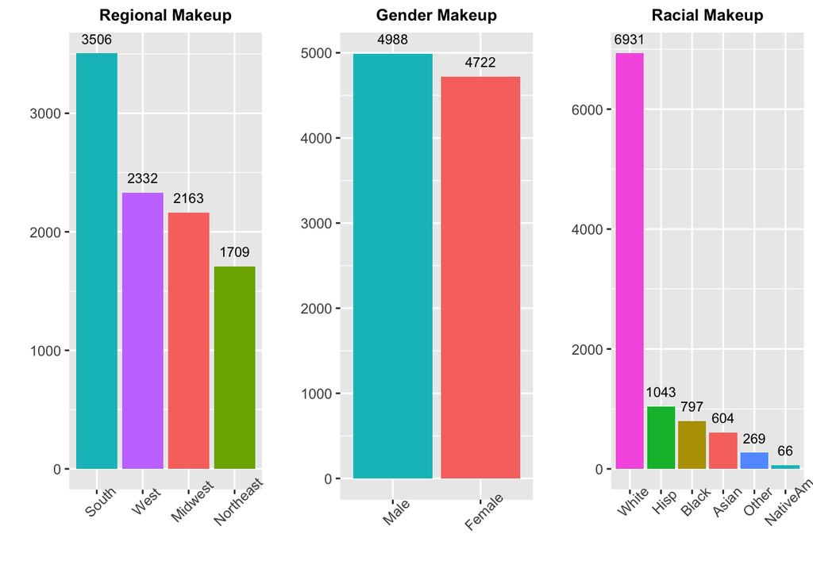

```r
suppressPackageStartupMessages(library(gridExtra))

# population by region
p1= countHist (xval=salaries$REGION, maintitle='Regional Makeup')

# by gender
p2=countHist (xval=salaries$SEX, maintitle='Gender Makeup')

#  by race
p3=countHist (xval=salaries$RACE, maintitle='Racial Makeup')

grid.arrange(p1, p2,p3, ncol=3, nrow = 1)
```

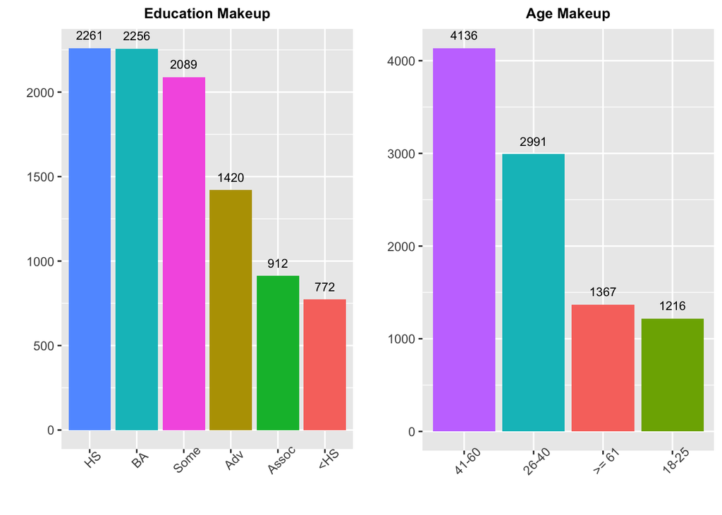

```r
# education, age
p4=countHist (xval=salaries$EDUCD, maintitle='Education Makeup')
p5=countHist (xval=salaries$AGE, maintitle='Age Makeup')

grid.arrange(p4,p5, ncol=2, nrow = 1)
```

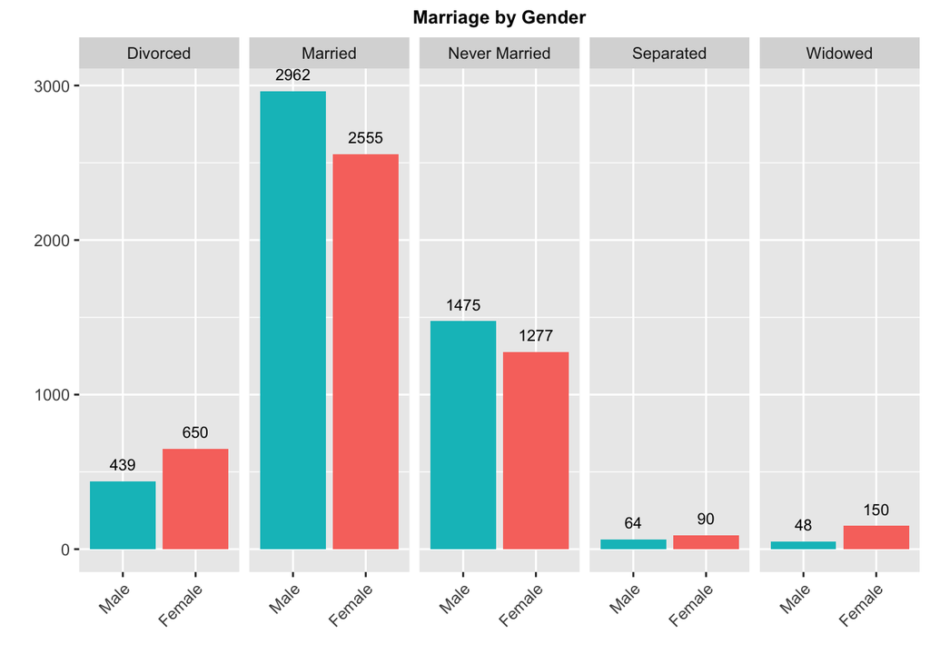

```r
# marital status by gender
histFacet (formulaVal= ~ salaries$MAR, xval=salaries$SEX, xtitle='', ytitle='', maintitle='Marriage by Gender')
```

```r
#t <- table(salaries$SEX, salaries$MAR)
#ftable(addmargins(t))
```

- The sample population is concentrated in the South, followed by West, Midwest and Northeast.
- Males are more represented (~51%) as compared to Females (~49%).
- Whites make up the majority at (6931), followed by Hispancis, Blacks, Asians, and Other. Native Americans are less than 100 at (66).
- For educational attainment, the population is fairly educated with a majority having high school, bachelors or some college. (1420) have advanced degrees while (912) has associates degree. Only (772) have less than high school.
- The majority of the sample are aged (41-60), followed by (26-40), then 61 years and older. The least represented age group is (18-25).
- Most people in this sample are married.

### Education by Group

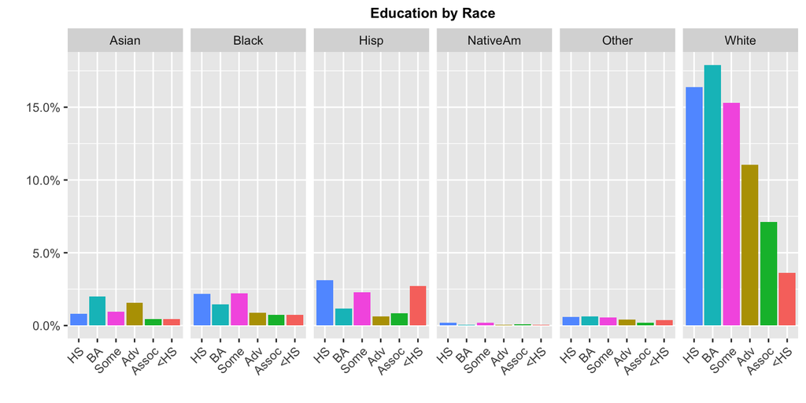

```r
# education by race
propHistFacet (~ salaries$RACE, salaries$EDUCD, xtitle='', ytitle='', maintitle='Education by Race')
```

Within the White group, education is right skewed with more whites having higher levels of education. For Hispanics, more have less than high school versus other racial groups. Within Blacks, the majority have HS or some college with less having earned a bachelor’s/advanced. Within Asians, more have bachelors or advanced degrees.

To validate these observations, I conduct a chi-square test to test whether there is a statistically significant relationship between education and race.

```r
# categorical testing

# 1-sample chi test
# X-squared = 1419, df = 5, p-value <0.0000000000000002
# indicates null hypothesis is rejected and there is a difference in edu levels
# edu <- chisq.test(x = table(salaries$EDUCD))

#2-sample chi test
# t-test to see if education levels are different between races
#t= table(salaries$EDUCD, salaries$RACE)
chi = chisq.test(x =table(salaries$EDUCD, salaries$RACE))
contrib <- 100*chi$residuals^2/chi$statistic
print (chi)
```

```
    Pearson's Chi-squared test

data:  table(salaries$EDUCD, salaries$RACE)
X-squared = 795.56, df = 25, p-value < 2.2e-16
```

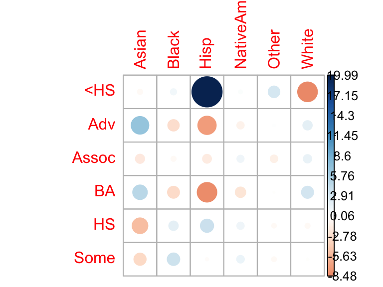

```r
#round(contrib, 4)  # contributions table

 # visualize Pearson residuals
suppressPackageStartupMessages(library(corrplot))
corrplot(chi$residuals,
         #mar=c(0,0,5,0),
         #number.cex=0.75,
         #title = 'Pearson Residuals plot',
         is.cor = FALSE)
```

```r
#corrplot(contrib, is.cor = FALSE) # Visualize the contribution

#s <- subset(x = salaries, subset = EDUCD %in% c("BA", "Adv"), select=c(EDUCD, RACE, INCWAGE))
#t = table (s$RACE, s$EDUCD)
#chisq.test(x = t)
```

The test statistic of 795.56 and a small p-value validates rejection of the null hypothesis, so we conclude there is a significant association betwen race and education.

From the Pearson Residuals plot we can see that Hispics are ‘strongly’ associated with less than high school with little association to BA/Advanced degress. Asians have a positive association with BA/Adv degrees (i.e. many more have higher level of education and this is larger than any other group). Blacks have a positive association with high school/some college and less to BA/Advance degrees. Within the White group, there is a negative association to less than high school (i.e. most complete high school) and moderate associations to degree attainment.

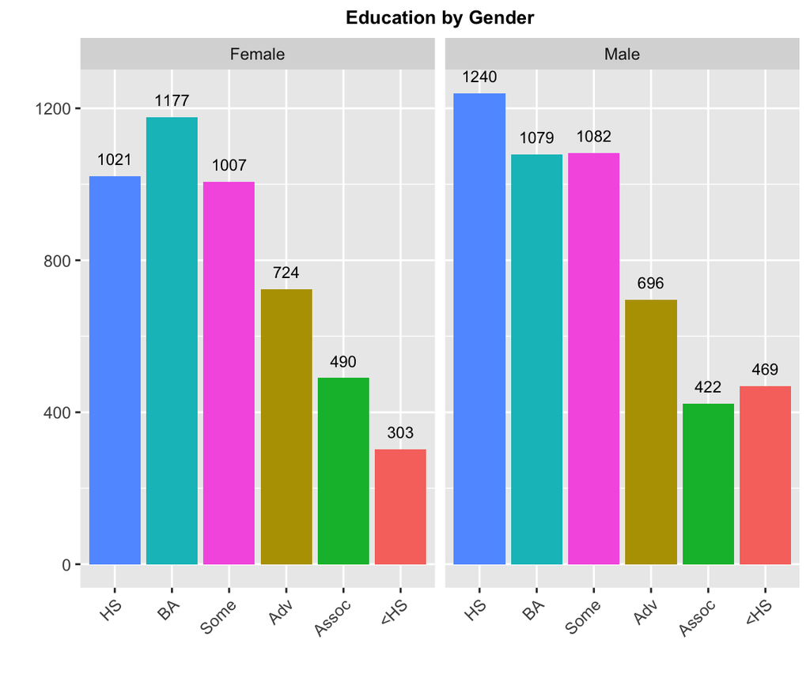

```r
# educ by gender
histFacet (formulaVal= ~ salaries$SEX, xval=salaries$EDUCD, xtitle='', ytitle='', maintitle='Education by Gender')
```

```r
# sex, age and education
#t <- table(salaries$SEX, salaries$AGE, salaries$EDUCD)
#ftable(addmargins(t))
```

As a group, women earn bachelors/advanced degrees at higher rates than men and the results of the chi-square test bears this out (significant X-squared of 62.238 and small pvalue). From the graph we can see that women are highly associated with higher education versus men.

```r
chi = chisq.test(x =table(salaries$SEX, salaries$EDUCD))
contrib <- 100*chi$residuals^2/chi$statistic
print (chi)
```

```
    Pearson's Chi-squared test

data:  table(salaries$SEX, salaries$EDUCD)
X-squared = 62.238, df = 5, p-value = 4.186e-12
```

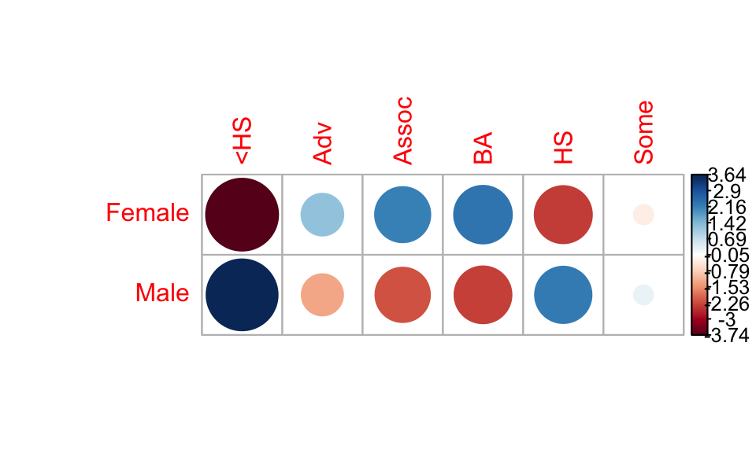

```r
 # visualize Pearson residuals
corrplot(chi$residuals, is.cor = FALSE)
```

### Income Analysis

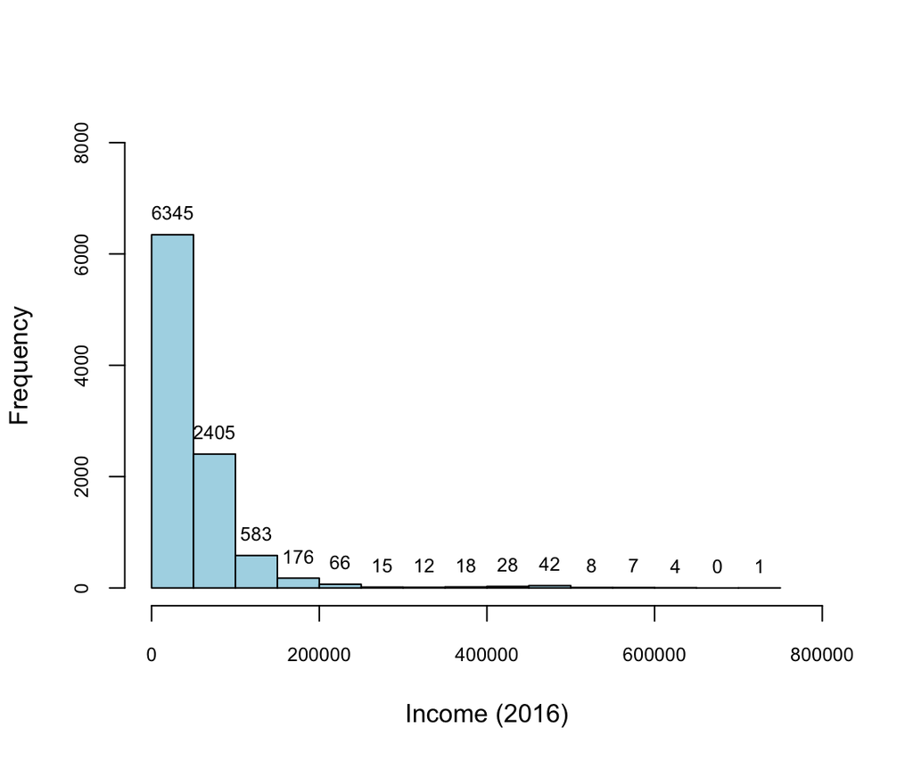

```r
par(mfrow=c(1, 1))
options(scipen=999) # don't want scientific notation for plots

h=hist(salaries$INCWAGE
     ,main = " "
     ,ylab = "Frequency"
     ,xlab = "Income (2016)",
     col = "lightblue",
     labels = FALSE,
     xlim=c(0,800000), ylim=c(0,8000),
     cex.lab=1, cex.axis=.75,
     breaks=15)
text(x=h$mids, y=h$counts, labels=h$counts,cex=.75,pos=3) # count labels
```

```r
options( scipen = 20, digits=4 )  # reenable it
```

From the histogram we can see income is right skewed with most income earned 100K or less. We also observe outliers at the far right with large incomes > than 450K. Income distribution is typically skewed right given very high incomes for relatively small segments of a population. Skewed data violates normality assumptions in regression models so income will need to be log transformed.

```r
showStats (df = salaries$INCWAGE)
```

```
 Min 1st Qu Median  Mean 3rd Qu    Max   COV   std   IQR
  10  19000  36400 51887  65000 710000 118.2 61346 46000
```

Income statistics reveals median income of ~36K while mean is ~52K, again an indication of positive skew. Moving on, lets explore income differences between different population groups.

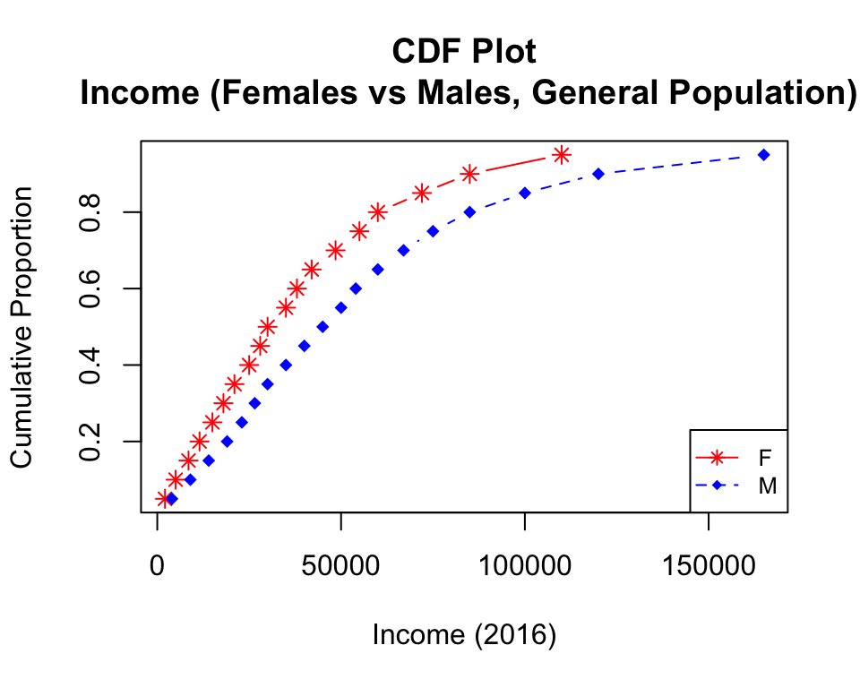

```r
#### Income by Gender

qvals = seq(0.05,0.95, by=0.05) # quantiles for the given probabilities
#qvals = seq(0, 1, by=0.05)

# Get income quantiles
finc = quantile(incomeF, probs=qvals)        # all females
fincEd = quantile(incomeColF, probs=qvals)   # college females
fincomeNo = quantile(incomeNoF, probs=qvals) # < college

minc = quantile(incomeM , probs=qvals)       # male income
mincEd = quantile(incomeColM, probs=qvals)   # colleged males
mincomeNo = quantile(incomeNoM, probs=qvals) # < college

# Find range of values
yrange = range(c(minc, finc))

# Using quantiles is a way to normalize the characteristics of a population between 0 and 1
# which facilitates comparisons between 2 populations while ignoring scale problems.
# High: last decile (q0.90), Middle: q0.90 − q0.95, Upper middle: q0.95 − q0.99
# really rich last centile (>= q0.99)

plotIncomes <- function(fIncome, fc, mIncome, mc, mtitle) {
  plot(y=qvals, x=fIncome,
     type="b",  # both points and lines
     pch=8,     # plotting character
     col=fc,
     xlim=yrange, ylab="Cumulative Proportion", xlab="Income (2016)",
     main= paste('CDF Plot\n',mtitle))
  lines(y=qvals, mIncome, pch=18, col=mc, type="b", lty=2) # male
}

par(mfrow=c(1, 1))

# female vs male, general
plotIncomes (fIncome =finc, fc='red', mIncome=minc, mc='blue',
             mtitle='Income (Females vs Males, General Population)')
legend(x="bottomright", y=95,
       legend=c('F', 'M'),
       col= c('red', 'blue'),
       pch = c(8, 18),
       lty=1:2, cex=0.8)
```

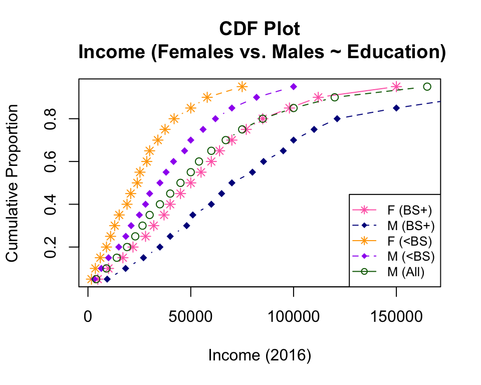

```r
# with and w/o college
plotIncomes (fIncome=fincEd, fc='hotpink', mIncome=mincEd, mc='darkblue',
             mtitle='Income (Females vs. Males ~ Education)')
lines(y=qvals, fincomeNo, pch=8, col="orange", type="b", lty=2)  # females none
lines(y=qvals, mincomeNo, pch=18, col="purple", type="b", lty=2)  # males none
lines(y=qvals, minc, col="darkgreen", type="b", lty=2) # all men

legend(x="bottomright", y=95,
       legend=c("F (BS+)", "M (BS+)", "F (<BS)", "M (<BS)", "M (All)"),
       col=c("hotpink","darkblue", "orange", "purple", "darkgreen"),
       pch = c(8, 18, 8, 18, 1),
       lty=1:2, cex=0.8)
```

In the cross tab table, we see that women earn higher levels of educaton than men, but does that translate to equal pay?  
To find out, a t-test is is run to see if earnings for college educated women, age (26-60) is different relative to their male counterparts.

```r
# t-test for college aged (26 -60)
sal = salaries[salaries$AGE %in% c("26-40", "41-60"),]
sal = sal[sal$EDUCD %in% c('Adv', 'BA'),]

addmargins(with(sal, table(sal$SEX, sal$EDUCD)))
```

```
          <HS  Adv Assoc   BA   HS Some  Sum
  Female    0  616     0  931    0    0 1547
  Male      0  532     0  844    0    0 1376
  Sum       0 1148     0 1775    0    0 2923
```

```r
fi = sal[sal$SEX == 'Female',]
mi = sal[sal$SEX == 'Male',]

# normality testing
#library("car")
# qqPlot(fi$INCWAGE)
# p-value > 0.05 implies the distribution are not significantly different from normal dist (i.e normal distribtion)
#shapiro.test(fi$INCWAGE)

#ttest <- t.test(fi$INCWAGE, mi$INCWAGE)
print(t.test(mi$INCWAGE, fi$INCWAGE))
```

```
    Welch Two Sample t-test

data:  mi$INCWAGE and fi$INCWAGE
t = 13, df = 2200, p-value <0.0000000000000002
alternative hypothesis: true difference in means is not equal to 0
95 percent confidence interval:
 32023 43788
sample estimates:
mean of x mean of y
   102428     64522
```

```r
#college women vs all men
ttest= t.test(fi$INCWAGE, incomeM)

print('Comparison: college Women vs. all Men')
```

```
[1] "Comparison: college Women vs. all Men"
```

```r
#writeLines(paste(ttest$method, "   t: ", ttest$statistic, " pvalue: ", ttest$"p.value"))
print (ttest)
```

```
    Welch Two Sample t-test

data:  fi$INCWAGE and incomeM
t = 1.7, df = 3119, p-value = 0.09
alternative hypothesis: true difference in means is not equal to 0
95 percent confidence interval:
 -469.2 6562.0
sample estimates:
mean of x mean of y
    64522     61476
```

There is a statistically significant difference between income between the two groups. The t statistic is 13 with a very low pvalue. See the striking differences between the mean of men vs women. So we reject the null hypothesis (no difference in mean incomes)and accept the alternate hypothesis.

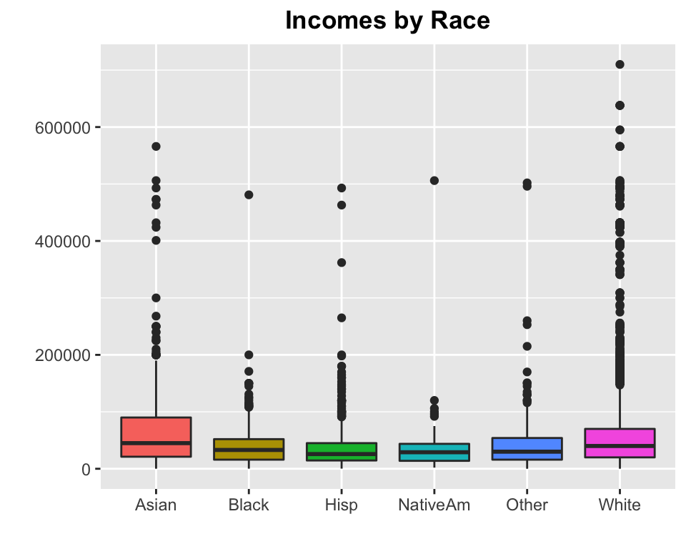

```r
#### income by race
par(mfrow=c(1, 1))

boxPlot (df=salaries, xval=salaries$RACE, yval= salaries$INCWAGE,
         xtitle='', ytitle=' ', maintitle = 'Incomes by Race')
```

Income differencees aren’t so wide among non-White, non-Asian groups. Asians are actually the highest earning, slightly surpassing whites. This may be due in part by higher levels of education attainment among Asians, generally.

To further analyze income differences between race, a one-way ANOVA test was conducted. The results find an F-stat of 38 and near 0 pvalue, indicatiing there is a significant difference in the group means of income amoung racial groups.  
However we don’t know which group means are different. For this the (Tukey Honest Significant Differences) is used for multiple pairwise-comparison between the means of groups.

```r
#one-way ANOVA for all races against income
# lm vs aov. not equivalent?
# aov does sequential sum of squares (Type I); lm does adjusted sum of squares (Type II).

fit <- aov(salaries$INCWAGE ~ salaries$RACE)
summary(fit)
```

```
                Df         Sum Sq      Mean Sq F value              Pr(>F)
salaries$RACE    5   700684946981 140136989396      38 <0.0000000000000002 ***
Residuals     9704 35837893050205   3693105220
---
Signif. codes:  0 '***' 0.001 '**' 0.01 '*' 0.05 '.' 0.1 ' ' 1
```

```r
# Perform multiple pairwise-comparison, to determine if the mean difference between specific
# pairs of group are statistically significant.
print(TukeyHSD(fit))
```

```
  Tukey multiple comparisons of means
    95% family-wise confidence level

Fit: aov(formula = salaries$INCWAGE ~ salaries$RACE)

$`salaries$RACE`
                 diff      lwr    upr  p adj
Black-Asian    -27954 -37298.9 -18610 0.0000
Hisp-Asian     -31295 -40151.9 -22439 0.0000
NativeAm-Asian -24287 -46742.9  -1831 0.0251
Other-Asian    -20415 -33111.8  -7718 0.0001
White-Asian    -10241 -17589.3  -2892 0.0010
Hisp-Black      -3341 -11490.1   4808 0.8519
NativeAm-Black   3667 -18519.0  25854 0.9971
Other-Black      7539  -4674.5  19753 0.4923
White-Black     17714  11235.1  24193 0.0000
NativeAm-Hisp    7008 -14977.2  28994 0.9445
Other-Hisp      10880   -964.6  22725 0.0929
White-Hisp      21055  15301.8  26807 0.0000
Other-NativeAm   3872 -19921.4  27665 0.9973
White-NativeAm  14046  -7376.0  35469 0.4215
White-Other     10174   -589.7  20938 0.0764
```

We see that the difference in means is not significant between Hipanic and Black, not too surprising given our understanding of pay disparity. Nor is it significant between Native American and Other race categories, but this might be explained by the relatively small sample size for NativeAm and Other, 66 and 269 respectively.

I then was wondering if the incomes of College, Asian males, age (26-60) differ from College, White males, so a t-test was conducted.

In the table below, we see that the population of Asians with college, age (26-60) is much smaller than that of a comparable population due to the relatively small Asian sample.

```r
#### colleged educated asians vs colleged educated whites
sal = salaries[salaries$AGE %in% c("26-40", "41-60"),]
sal = sal[sal$EDUCD %in% c('Adv', 'BA'),]
sal = sal[sal$RACE %in% c('Asian', 'White'),]

table(sal$RACE)
```

```
   Asian    Black     Hisp NativeAm    Other    White
     295        0        0        0        0     2206
```

```r
addmargins(with(sal, table(sal$RACE, sal$EDUCD)))
```

```
            <HS  Adv Assoc   BA   HS Some  Sum
  Asian       0  143     0  152    0    0  295
  Black       0    0     0    0    0    0    0
  Hisp        0    0     0    0    0    0    0
  NativeAm    0    0     0    0    0    0    0
  Other       0    0     0    0    0    0    0
  White       0  841     0 1365    0    0 2206
  Sum         0  984     0 1517    0    0 2501
```

```r
asianm = sal[sal$RACE == 'Asian' & sal$SEX == 'Male',]
whitem = sal[sal$RACE == 'White' & sal$SEX == 'Male',]
print(t.test(asianm$INCWAGE, whitem$INCWAGE))
```

```
    Welch Two Sample t-test

data:  asianm$INCWAGE and whitem$INCWAGE
t = 0.096, df = 214, p-value = 0.9
alternative hypothesis: true difference in means is not equal to 0
95 percent confidence interval:
 -14808  16328
sample estimates:
mean of x mean of y
   107667    106907
```

The t-test results are not signficant and we see the means are not substantially different, 107667 vs 106907 between Asian and White men, respectively. While we can’t reject the null hypothesis, the sample size for Asians in this group is quite small compared to Whites. Let’s run another t-test that compares all Asians as a group relative to all Whites as a group.

```r
#### all asians vs all educated whites
sal = salaries[salaries$RACE %in% c('Asian', 'White'),]
#table(sal$RACE)

asian = sal[sal$RACE == 'Asian',]
white = sal[sal$RACE == 'White',]
print(t.test(asian$INCWAGE, white$INCWAGE))
```

```
    Welch Two Sample t-test

data:  asian$INCWAGE and white$INCWAGE
t = 3.4, df = 692, p-value = 0.0007
alternative hypothesis: true difference in means is not equal to 0
95 percent confidence interval:
  4302 16179
sample estimates:
mean of x mean of y
    65584     55343
```

This time the t statistic is 3.4 with a significant pvalue, so we can say that mean income is different between Asians versus Whites, thus confirming the results in the data that Asian’s earn more as a group than all other groups, but only slightly different from Whites.

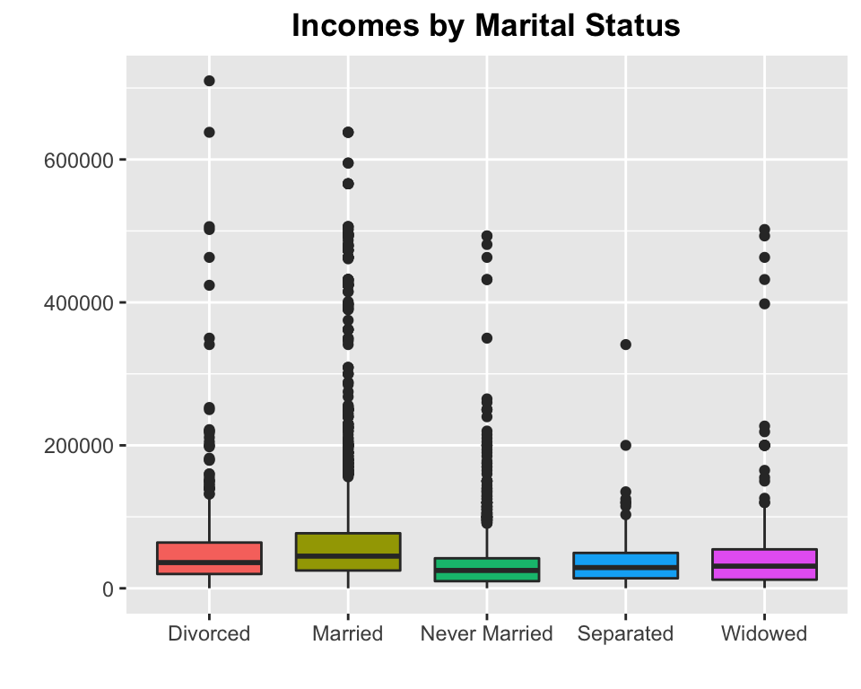

```r
#### income by marital status
par(mfrow=c(1, 1))

boxPlot (df=salaries, xval=salaries$MAR, yval= salaries$INCWAGE,
         xtitle='', ytitle=' ', maintitle = 'Incomes by Marital Status')
```

In looking at incomes by marital status, it seems being married now or or previously (divorced, widowed) results in higher income. Married persons have the highest incomes relative to the other groups. This intuitvely makes sense given multiple workers in the family. To find out about the statisical significance, an ANOVA test is conducted.

```r
#table(salaries$MAR)

fit <- aov(salaries$INCWAGE ~ salaries$MAR)
print(summary(fit))
```

```
               Df         Sum Sq      Mean Sq F value              Pr(>F)
salaries$MAR    4  1665745644703 416436411176     116 <0.0000000000000002 ***
Residuals    9705 34872832352484   3593285147
---
Signif. codes:  0 '***' 0.001 '**' 0.01 '*' 0.05 '.' 0.1 ' ' 1
```

```r
print(fit$coefficients)
```

```
              (Intercept)       salaries$MARMarried salaries$MARNever Married
                    48904                     13496                    -16207
    salaries$MARSeparated       salaries$MARWidowed
                   -11510                      4466
```

The findings of ANOVA reveal a high F value of 116 and a very significant pvalue, indicating there is a statistically signficant difference in mean incomes by marital status.

Looking at the coefficients, with Divorced (48904) as the intercept.  
The regression equation: **INC = 48904 + 13496(Married) -16207(Never Married) -11510 (Separated) + 4466 (Widowed)**. Relative to Divorced, Married earns (13496) more; Never Married earns (16207) less; Separated earns (11510) less; Widowed earns (4466) more.

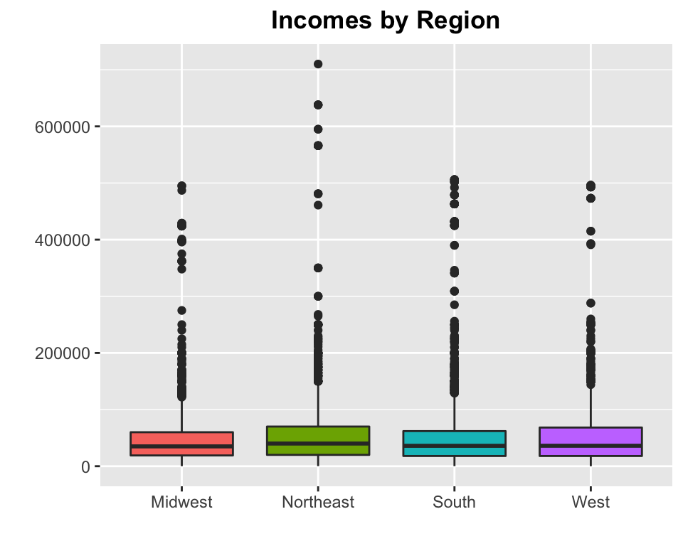

```r
#### income by region
boxPlot (df=salaries, xval=salaries$REGION, yval= salaries$INCWAGE,
         xtitle='', ytitle=' ', maintitle = 'Incomes by Region')
```

Mean incomes across all regions are not that different, but the higher incomes look to be more concentrated in the Northeast and West. Intuitively this makes given that higher paying jobs are more concentrated in these areas.

To find out the statistical signficance of regional income differences, an ANOVA test was conducted.

```r
#table(salaries$REGION)

# f = lm (salaries$INCWAGE ~ salaries$REGION)
# Anova(f)
# s = summary(f)
# same results as below but summary has more detail, R2, etc..

fit <- aov(salaries$INCWAGE ~ salaries$REGION)
print(summary(fit))
```

```
                  Df         Sum Sq     Mean Sq F value Pr(>F)
salaries$REGION    3    79275225099 26425075033    7.03 0.0001 ***
Residuals       9706 36459302772088  3756367481
---
Signif. codes:  0 '***' 0.001 '**' 0.01 '*' 0.05 '.' 0.1 ' ' 1
```

```r
print(fit$coefficients)
```

```
             (Intercept) salaries$REGIONNortheast     salaries$REGIONSouth      salaries$REGIONWest
                   48775                     8606                     1864                     3850
```

The findings of ANOVA reveal an F value of 7.03 and a significant pvalue, indicating there is a statistically signficance difference in mean income by region. Looking at the coefficients, the mean in the MidWest (Intercept) is (48775).  
The regression equation: **INC = 48775 + 8606(NE) + 1864(S) + 3850(W)** indicates the Midwest has the lowest income at 48775. Relative to the MW, Northeast has earnings 8606 more; South has 1864; West has 3850 more. This confirms what we see visually with Northeast followed by West having the highest median earnings.

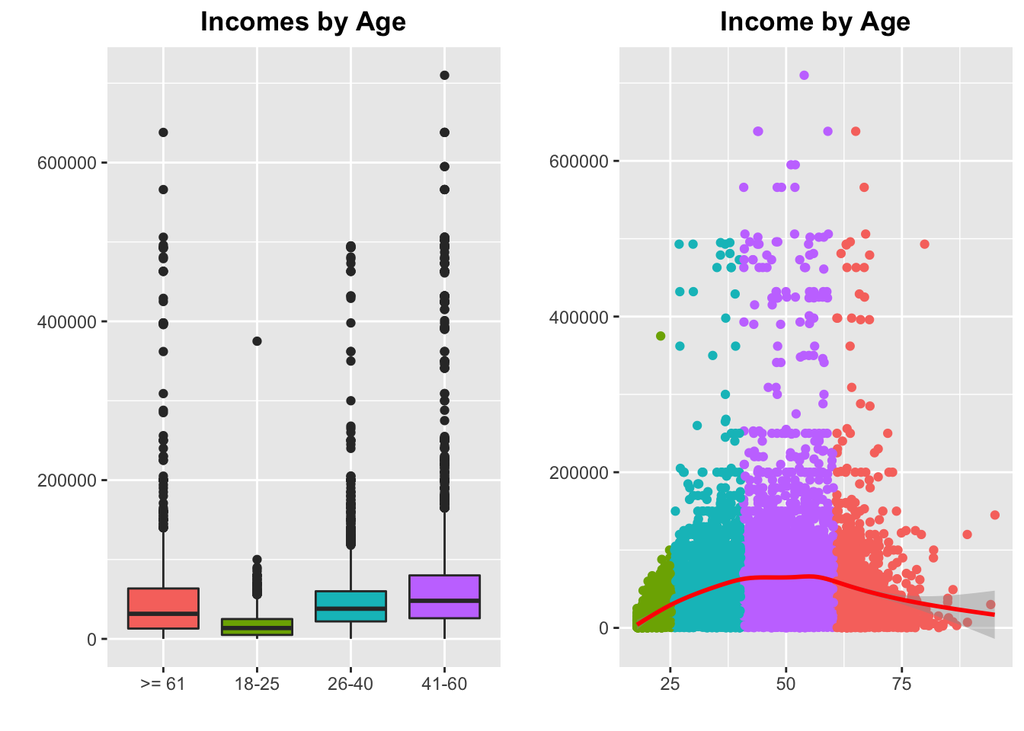

```r
####  income given age

p1= boxPlot (df=salaries, xval=salaries$AGE, yval= salaries$INCWAGE,
         xtitle='', ytitle=' ', maintitle = 'Incomes by Age')

# scatter plot
p2 = ggplot(salariesOrg,
        aes(x=jitter(as.numeric(salariesOrg$AGE)), y=salariesOrg$INCWAGE,
        color=salaries$AGE)) +
        labs(title="Income by Age", x ="", y = "")+
        geom_point(show.legend=FALSE) +   # scatter
        #regression line
        #https://stackoverflow.com/questions/30208670/r-stat-smooth-groups-x-axis
        theme(plot.title = element_text(hjust = 0.5, face="bold")) +
        geom_smooth(color='red') # Loess method

grid.arrange(p1,p2, ncol=2, nrow = 1)
```

Looking at income by age, we see income generally increases with age during employment years but gradually decreases ~ 60. The highest income occurs during age 41-60, likely corresponding to established careers during prime working years.

To find out the statistical signficance of Age income differences, an ANOVA test was conducted.

```r
#table(salaries$AGE)

fit <- aov(salaries$INCWAGE ~ salaries$AGE)
print(summary(fit))
```

```
               Df         Sum Sq      Mean Sq F value              Pr(>F)
salaries$AGE    3  2117310631460 705770210487     199 <0.0000000000000002 ***
Residuals    9706 34421267365727   3546390621
---
Signif. codes:  0 '***' 0.001 '**' 0.01 '*' 0.05 '.' 0.1 ' ' 1
```

```r
print(fit$coefficients)
```

```
      (Intercept) salaries$AGE18-25 salaries$AGE26-40 salaries$AGE41-60
            50115            -31957             -1628             14735
```

The findings of ANOVA reveal a very large F value of 199 and a very significant pvalue, indicating there is a statistically signficance difference in mean income levels by age.  
Looking at the coefficients, the intercept of (50115) corresponds to persons over 60. Using this group as a point of reference, we see the (18-25) group earns less by (31957). (26-40) earn less by (1628) and (41-60) earn more by (14735). This is in alignment with what we see visually.

### Regression Models

#### Linear Regression

Next, multiple regression models are analyzed to assess the influence of the variables studied during Descriptive Statistics on income. (Note that I took the log of income due to high positive skew. As monetary amounts usually have a log-normal distributiong, taking the log restores symmetry).

##### Model1: log(INCWAGE) ~ AGE + SEX + RACE

```r
model1 = lm(log(INCWAGE) ~ AGE + SEX + RACE, data = salaries)
summary (model1)
```

```
Call:
lm(formula = log(INCWAGE) ~ AGE + SEX + RACE, data = salaries)

Residuals:
   Min     1Q Median     3Q    Max
-8.448 -0.470  0.147  0.675  3.327

Coefficients:
             Estimate Std. Error t value             Pr(>|t|)
(Intercept)   10.1292     0.0543  186.44 < 0.0000000000000002 ***
AGE18-25      -0.8643     0.0434  -19.93 < 0.0000000000000002 ***
AGE26-40       0.2676     0.0359    7.45    0.000000000000098 ***
AGE41-60       0.5027     0.0342   14.70 < 0.0000000000000002 ***
SEXMale        0.3994     0.0222   17.96 < 0.0000000000000002 ***
RACEBlack     -0.3710     0.0590   -6.29    0.000000000340292 ***
RACEHisp      -0.4609     0.0560   -8.22 < 0.0000000000000002 ***
RACENativeAm  -0.3058     0.1419   -2.16              0.03114 *
RACEOther     -0.2808     0.0803   -3.50              0.00047 ***
RACEWhite     -0.1570     0.0464   -3.38              0.00073 ***
---
Signif. codes:  0 '***' 0.001 '**' 0.01 '*' 0.05 '.' 0.1 ' ' 1

Residual standard error: 1.09 on 9700 degrees of freedom
Multiple R-squared:  0.171, Adjusted R-squared:  0.17
F-statistic:  223 on 9 and 9700 DF,  p-value: <0.0000000000000002
```

The F-statistic with its very low pvalue is highly significant. All the predictor variables (Age, Sex and Race) also have significant t-statistic values, though NativeAm is marginal. The Adjusted R-squared (0.17) indicates that about 17% of Income is explained by this model.

##### Model2: log(INCWAGE) ~ AGE + SEX + RACE + EDUCD

Additon of (Education)

```r
# sames as model1
#model2 = glm(log10(INCWAGE) ~ AGE + SEX + MAR + REGION + RACE, data = salaries, family=gaussian)
model2 = lm(log(INCWAGE) ~ AGE + SEX + RACE + EDUCD, data = salaries)
summary (model2)
```

```
Call:
lm(formula = log(INCWAGE) ~ AGE + SEX + RACE + EDUCD, data = salaries)

Residuals:
   Min     1Q Median     3Q    Max
-8.346 -0.390  0.170  0.618  3.509

Coefficients:
             Estimate Std. Error t value             Pr(>|t|)
(Intercept)    9.2809     0.0636  145.98 < 0.0000000000000002 ***
AGE18-25      -0.7484     0.0413  -18.13 < 0.0000000000000002 ***
AGE26-40       0.2207     0.0340    6.50       0.000000000085 ***
AGE41-60       0.4924     0.0323   15.25 < 0.0000000000000002 ***
SEXMale        0.4484     0.0211   21.30 < 0.0000000000000002 ***
RACEBlack     -0.1702     0.0561   -3.03               0.0024 **
RACEHisp      -0.0999     0.0540   -1.85               0.0642 .
RACENativeAm  -0.0377     0.1342   -0.28               0.7790
RACEOther     -0.1213     0.0759   -1.60               0.1100
RACEWhite     -0.0525     0.0440   -1.19               0.2333
EDUCDAdv       1.2689     0.0476   26.64 < 0.0000000000000002 ***
EDUCDAssoc     0.6095     0.0515   11.84 < 0.0000000000000002 ***
EDUCDBA        1.0404     0.0445   23.36 < 0.0000000000000002 ***
EDUCDHS        0.3815     0.0438    8.72 < 0.0000000000000002 ***
EDUCDSome      0.5483     0.0445   12.33 < 0.0000000000000002 ***
---
Signif. codes:  0 '***' 0.001 '**' 0.01 '*' 0.05 '.' 0.1 ' ' 1

Residual standard error: 1.03 on 9695 degrees of freedom
Multiple R-squared:  0.262, Adjusted R-squared:  0.261
F-statistic:  246 on 14 and 9695 DF,  p-value: <0.0000000000000002
```

With the addition of (Education), the F-statistic is still highly significant. Age and Sex continue to be significant, but Race is much less so with only Black being significant, but less than before. However Education is very signficant. The Adjusted R-squared (0.261) increased, indicating that about 26% of Income is explained by this model.

##### Model3: log(INCWAGE) ~ AGE + SEX + RACE + EDUCD + MAR

Addition of (Marriage)

```r
model3 = lm(log(INCWAGE) ~ AGE + SEX + RACE + EDUCD + MAR, data = salaries)
summary (model3)
```

```
Call:
lm(formula = log(INCWAGE) ~ AGE + SEX + RACE + EDUCD + MAR, data = salaries)

Residuals:
   Min     1Q Median     3Q    Max
-8.431 -0.394  0.172  0.614  3.516

Coefficients:
                 Estimate Std. Error t value             Pr(>|t|)
(Intercept)        9.2140     0.0696  132.34 < 0.0000000000000002 ***
AGE18-25          -0.5396     0.0468  -11.52 < 0.0000000000000002 ***
AGE26-40           0.2991     0.0352    8.49 < 0.0000000000000002 ***
AGE41-60           0.5041     0.0324   15.55 < 0.0000000000000002 ***
SEXMale            0.4470     0.0211   21.18 < 0.0000000000000002 ***
RACEBlack         -0.1265     0.0559   -2.26                0.024 *
RACEHisp          -0.0859     0.0537   -1.60                0.110
RACENativeAm       0.0220     0.1335    0.16                0.869
RACEOther         -0.0943     0.0755   -1.25                0.212
RACEWhite         -0.0485     0.0438   -1.11                0.268
EDUCDAdv           1.2430     0.0475   26.17 < 0.0000000000000002 ***
EDUCDAssoc         0.6003     0.0512   11.72 < 0.0000000000000002 ***
EDUCDBA            1.0302     0.0444   23.21 < 0.0000000000000002 ***
EDUCDHS            0.3819     0.0435    8.77 < 0.0000000000000002 ***
EDUCDSome          0.5494     0.0442   12.42 < 0.0000000000000002 ***
MARMarried         0.1132     0.0344    3.29                0.001 **
MARNever Married  -0.1877     0.0408   -4.60            0.0000042 ***
MARSeparated      -0.1558     0.0889   -1.75                0.080 .
MARWidowed         0.0648     0.0801    0.81                0.418
---
Signif. codes:  0 '***' 0.001 '**' 0.01 '*' 0.05 '.' 0.1 ' ' 1

Residual standard error: 1.03 on 9691 degrees of freedom
Multiple R-squared:  0.271, Adjusted R-squared:  0.27
F-statistic:  200 on 18 and 9691 DF,  p-value: <0.0000000000000002
```

With the additon of (Marriage), Age, Sex, Education continue to be significant. Race continues not to be very significant. For Marriage, only Married and Never-married is signficant. The F-statistic is still highly significant, while the Adjusted R-squared (0.27), did not change much from the previous model (0.261).

##### Model4: log(INCWAGE) ~ AGE + SEX + RACE + EDUCD + MAR + REGION

Addition of Region

```r
model4 = lm(log(INCWAGE) ~ AGE + SEX + RACE + EDUCD + MAR + REGION, data = salaries)
summary (model4)
```

```
Call:
lm(formula = log(INCWAGE) ~ AGE + SEX + RACE + EDUCD + MAR +
    REGION, data = salaries)

Residuals:
   Min     1Q Median     3Q    Max
-8.465 -0.390  0.170  0.613  3.568

Coefficients:
                 Estimate Std. Error t value             Pr(>|t|)
(Intercept)        9.1394     0.0734  124.43 < 0.0000000000000002 ***
AGE18-25          -0.5318     0.0468  -11.36 < 0.0000000000000002 ***
AGE26-40           0.3041     0.0352    8.63 < 0.0000000000000002 ***
AGE41-60           0.5056     0.0324   15.61 < 0.0000000000000002 ***
SEXMale            0.4457     0.0211   21.14 < 0.0000000000000002 ***
RACEBlack         -0.0919     0.0569   -1.61              0.10645
RACEHisp          -0.0811     0.0537   -1.51              0.13090
RACENativeAm       0.0224     0.1335    0.17              0.86693
RACEOther         -0.0904     0.0755   -1.20              0.23121
RACEWhite         -0.0237     0.0444   -0.53              0.59367
EDUCDAdv           1.2385     0.0475   26.10 < 0.0000000000000002 ***
EDUCDAssoc         0.5966     0.0512   11.66 < 0.0000000000000002 ***
EDUCDBA            1.0261     0.0444   23.14 < 0.0000000000000002 ***
EDUCDHS            0.3824     0.0435    8.79 < 0.0000000000000002 ***
EDUCDSome          0.5490     0.0442   12.42 < 0.0000000000000002 ***
MARMarried         0.1133     0.0344    3.29              0.00099 ***
MARNever Married  -0.1970     0.0408   -4.83            0.0000014 ***
MARSeparated      -0.1613     0.0888   -1.82              0.06936 .
MARWidowed         0.0670     0.0800    0.84              0.40234
REGIONNortheast    0.1261     0.0333    3.78              0.00016 ***
REGIONSouth        0.0220     0.0284    0.78              0.43801
REGIONWest         0.1052     0.0319    3.30              0.00099 ***
---
Signif. codes:  0 '***' 0.001 '**' 0.01 '*' 0.05 '.' 0.1 ' ' 1

Residual standard error: 1.02 on 9688 degrees of freedom
Multiple R-squared:  0.273, Adjusted R-squared:  0.271
F-statistic:  173 on 21 and 9688 DF,  p-value: <0.0000000000000002
```

With the addition of (Region), Age, Sex, Education continue to be significant, but Race is no longer significant. For marriage, only Married and Never-married are significant. For region, only Northeast and West are significant. The F-statistic is still highly significant and the Adjusted R-squared (0.271) is about the same as the last model (0.27).

At this point, it appears that Age, Sex and Educaton have the strongest effect on on income. The addition of Education, reduced the effect of Race, which makes sense given that we know that education has a leveling power. Married and Never-married; Northeast and West also show a strong effect.

Next compare the 4 models’ fit using anova f-test.

##### Model comparisons

```r
anova(model1, model2, model3, model4)
```

```
Analysis of Variance Table

Model 1: log(INCWAGE) ~ AGE + SEX + RACE
Model 2: log(INCWAGE) ~ AGE + SEX + RACE + EDUCD
Model 3: log(INCWAGE) ~ AGE + SEX + RACE + EDUCD + MAR
Model 4: log(INCWAGE) ~ AGE + SEX + RACE + EDUCD + MAR + REGION
  Res.Df   RSS Df Sum of Sq      F               Pr(>F)
1   9700 11601
2   9695 10325  5      1276 242.87 < 0.0000000000000002 ***
3   9691 10202  4       124  29.43 < 0.0000000000000002 ***
4   9688 10178  3        24   7.56             0.000048 ***
---
Signif. codes:  0 '***' 0.001 '**' 0.01 '*' 0.05 '.' 0.1 ' ' 1
```

From these results, it appears that Model2 (AGE + SEX + RACE + EDUCD) and Model3 (AGE + SEX + RACE + EDUCD + MAR) are the best fit. Comparing just these two, the anova f-test shows that Model3 is the better choice.

```r
anova(model2, model3)
```

```
Analysis of Variance Table

Model 1: log(INCWAGE) ~ AGE + SEX + RACE + EDUCD
Model 2: log(INCWAGE) ~ AGE + SEX + RACE + EDUCD + MAR
  Res.Df   RSS Df Sum of Sq    F              Pr(>F)
1   9695 10325
2   9691 10202  4       124 29.4 <0.0000000000000002 ***
---
Signif. codes:  0 '***' 0.001 '**' 0.01 '*' 0.05 '.' 0.1 ' ' 1
```

And yet when we look at the coefficeints for RACE in Model3, they are not very significant with only Black being marginally significant, so let’s create another model that eliminates RACE and compare it.

```r
summary(model3)$coefficient
```

```
                 Estimate Std. Error  t value   Pr(>|t|)
(Intercept)       9.21396    0.06963 132.3369  0.000e+00
AGE18-25         -0.53956    0.04682 -11.5246  1.568e-30
AGE26-40          0.29913    0.03524   8.4890  2.390e-17
AGE41-60          0.50415    0.03242  15.5494  7.169e-54
SEXMale           0.44696    0.02110  21.1849  2.080e-97
RACEBlack        -0.12653    0.05594  -2.2621  2.371e-02
RACEHisp         -0.08586    0.05368  -1.5993  1.098e-01
RACENativeAm      0.02203    0.13353   0.1650  8.690e-01
RACEOther        -0.09435    0.07554  -1.2490  2.117e-01
RACEWhite        -0.04849    0.04381  -1.1068  2.684e-01
EDUCDAdv          1.24301    0.04749  26.1726 5.936e-146
EDUCDAssoc        0.60029    0.05121  11.7213  1.617e-31
EDUCDBA           1.03019    0.04438  23.2118 4.872e-116
EDUCDHS           0.38195    0.04354   8.7732  2.029e-18
EDUCDSome         0.54940    0.04424  12.4184  3.840e-35
MARMarried        0.11319    0.03443   3.2874  1.015e-03
MARNever Married -0.18765    0.04076  -4.6034  4.210e-06
MARSeparated     -0.15575    0.08886  -1.7529  7.966e-02
MARWidowed        0.06480    0.08009   0.8091  4.185e-01
```

##### Model5: log(INCWAGE) ~ AGE + SEX + EDUCD + MAR

```r
model5 = lm(log(INCWAGE) ~ AGE + SEX + EDUCD + MAR, data = salaries)
summary (model5)
```

```
Call:
lm(formula = log(INCWAGE) ~ AGE + SEX + EDUCD + MAR, data = salaries)

Residuals:
   Min     1Q Median     3Q    Max
-8.470 -0.393  0.172  0.616  3.598

Coefficients:
                 Estimate Std. Error t value             Pr(>|t|)
(Intercept)        9.1466     0.0545  167.87 < 0.0000000000000002 ***
AGE18-25          -0.5409     0.0467  -11.58 < 0.0000000000000002 ***
AGE26-40           0.2962     0.0351    8.44 < 0.0000000000000002 ***
AGE41-60           0.5029     0.0324   15.54 < 0.0000000000000002 ***
SEXMale            0.4480     0.0211   21.26 < 0.0000000000000002 ***
EDUCDAdv           1.2585     0.0463   27.19 < 0.0000000000000002 ***
EDUCDAssoc         0.6114     0.0504   12.14 < 0.0000000000000002 ***
EDUCDBA            1.0449     0.0431   24.27 < 0.0000000000000002 ***
EDUCDHS            0.3894     0.0428    9.09 < 0.0000000000000002 ***
EDUCDSome          0.5579     0.0434   12.86 < 0.0000000000000002 ***
MARMarried         0.1169     0.0344    3.40              0.00068 ***
MARNever Married  -0.1895     0.0407   -4.66            0.0000033 ***
MARSeparated      -0.1620     0.0887   -1.83              0.06788 .
MARWidowed         0.0670     0.0801    0.84              0.40315
---
Signif. codes:  0 '***' 0.001 '**' 0.01 '*' 0.05 '.' 0.1 ' ' 1

Residual standard error: 1.03 on 9696 degrees of freedom
Multiple R-squared:  0.271, Adjusted R-squared:  0.27
F-statistic:  277 on 13 and 9696 DF,  p-value: <0.0000000000000002
```

```r
anova(model3, model5)
```

```
Analysis of Variance Table

Model 1: log(INCWAGE) ~ AGE + SEX + RACE + EDUCD + MAR
Model 2: log(INCWAGE) ~ AGE + SEX + EDUCD + MAR
  Res.Df   RSS Df Sum of Sq    F Pr(>F)
1   9691 10202
2   9696 10209 -5     -7.67 1.46    0.2
```

```r
# these are equivalent?
model1 = lm(log(INCWAGE) ~ AGE + SEX + RACE, data = salaries)
model2 = glm(log(INCWAGE) ~ AGE + SEX + RACE, data = salaries, family=gaussian)
anova(model1, model2, model3)
```

```
Analysis of Variance Table

Model 1: log(INCWAGE) ~ AGE + SEX + RACE
Model 2: log(INCWAGE) ~ AGE + SEX + RACE
Model 3: log(INCWAGE) ~ AGE + SEX + RACE + EDUCD + MAR
  Res.Df   RSS Df Sum of Sq   F              Pr(>F)
1   9700 11601
2   9700 11601  0         0
3   9691 10202  9      1399 148 <0.0000000000000002 ***
---
Signif. codes:  0 '***' 0.001 '**' 0.01 '*' 0.05 '.' 0.1 ' ' 1
```

Everyting looks significant but the Adjusted R-squared: (0.27) is the same as Model3 which is supported by the anova results, indicating ~27% of Income levels is explained by this model. However, given that Model5 is a simpler model, it is the best model.

#### Logistic regression

Predict the probability of poverty based on age, sex, education, and health coverage.

For this analysis, I’ve defined Poverty as:**(POVPIP < 150 | PAP > 0 )** where POVIP is 3-digit numeric code expressing a total income as a percentage of the poverty thresholds established by the SSA. PAP is the amount of public assistance received.

```r
poverty <- glm(POVPIP ~ AGE2 + SEX + EDUCD + HICOV + RACE,
                 data=salaries, family="binomial",
                 )
#coefficients in regression explain how much a variables contribute to the log odds of the response
#  transforming the log-odds to odds for easier interpretation
poverty.tab <-  coef(summary(poverty))
poverty.tab[, "Estimate"] <- exp(coef(poverty))
poverty.tab
```

```
             Estimate Std. Error  z value  Pr(>|z|)
(Intercept)    1.2436   0.174108   1.2523 2.105e-01
AGE2           0.9767   0.001992 -11.8301 2.728e-32
SEXMale        0.7711   0.056268  -4.6207 3.825e-06
EDUCDAdv       0.1514   0.142503 -13.2479 4.638e-40
EDUCDAssoc     0.5410   0.118672  -5.1761 2.266e-07
EDUCDBA        0.2450   0.110556 -12.7225 4.432e-37
EDUCDHS        0.6127   0.095463  -5.1308 2.885e-07
EDUCDSome      0.5242   0.099105  -6.5178 7.133e-11
HICOV2         2.0674   0.082059   8.8510 8.673e-19
RACEBlack      1.4486   0.150708   2.4591 1.393e-02
RACEHisp       1.3230   0.144103   1.9425 5.207e-02
RACENativeAm   1.2030   0.323651   0.5711 5.680e-01
RACEOther      2.0581   0.185879   3.8830 1.032e-04
RACEWhite      0.9762   0.127757  -0.1883 8.507e-01
```

Most of the coefficient p-values are are statistically significant in determining poverty with the exception of some of the race groups; only Other is very significant while Blacks and Hispanics are marginally significant. NativeAmericans (likely due to small sample size) and Whites are not signifant at all. Overall the results suggest the model is a good fit in predicting poverty.

- AGE2: With increased age, the odds of poverty **‘decreases’** by 0.9767.
- SEXMale: Males have **‘decreased’** odds of poverty of 0.7711.
- EDUCDAdv: Advance degrees relative to less than HS **‘decreases’** the odd of poverty by 0.1514.
- EDUCDAssoc: Assoc degrees relative to less than HS **‘decreases’** the odds of poverty by 0.5410
- EDUCDBA: Bachelors degree relative to less than HS **‘decreases’** the odds of poverty by 0.2450
- EDUCDHS: HS diplomas relatve to less than HS **‘decreases’** the odds of poverty by 0.6127
- EDUCDSome: Some college relative to less than HS **‘decreases’** the odds of poverty 0.5242
- HICOV2: Not having health coverage **‘increases’** the odds of poverty by 2.0674
- RACEBlack: Relative to Asians, Blacks have an **‘increased’** odds of poverty of 1.4486
- RACEHisp: Relative to Asians, Hispancis have an **‘increased’** odds of poverty of 1.3230
- RACENativeAm: Relative to Asians, NativeAm have an **‘increased’** odds of poverty of 1.2030
- RACEOther: Relative to Asians, Others races have an **‘increased’** odds of poverty of 2.0581
- RACEWhite: Relative to Asians, Whites relative have a **‘descreased’** odds of poverty of 0.9762

The following plots visually shows the effects of these factors on poverty. (Note: the poverty scale is in log odds vs. odds given the plotting library).

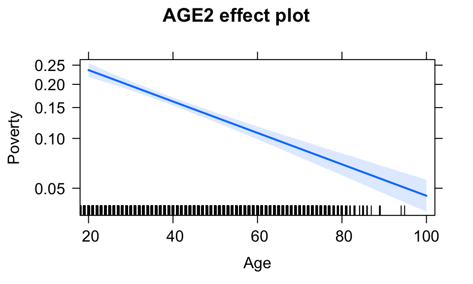

```r
suppressPackageStartupMessages(library(effects))

plotEffect <- function(ef, mtitle='', ytitle='', xtitle='', cName) {
 plot(ef, cName,
     main = mtitle, xlab = ytitle, ylab = xtitle)
}

eff = allEffects(poverty)
#summary(eff)
#plot(eff)  # too squished

plotEffect(eff,cName= 'AGE2', mtitle = 'AGE2 effect plot', xtitle = 'Poverty', ytitle = 'Age')
```

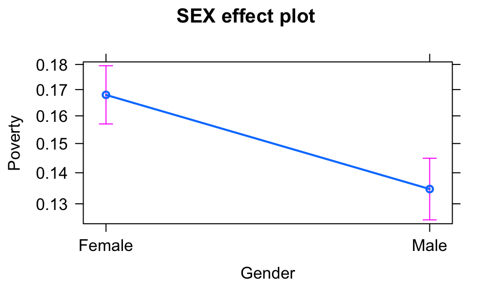

```r
plotEffect(eff,cName='SEX', mtitle = 'SEX effect plot', xtitle = 'Poverty', ytitle = 'Gender')
```

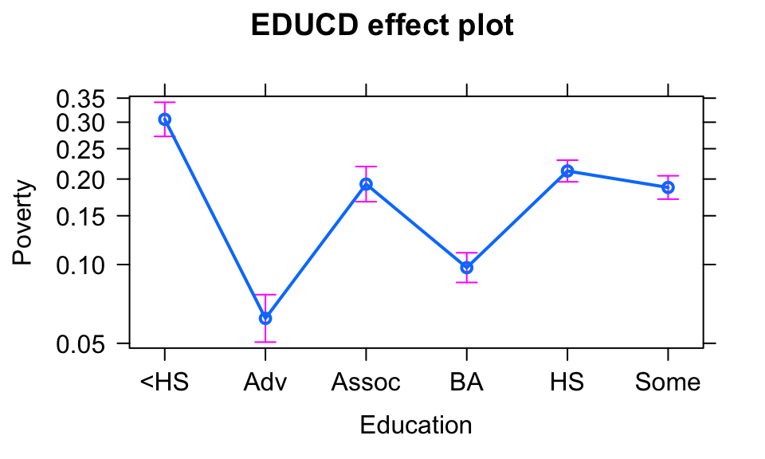

```r
plotEffect(eff, cName='EDUCD',mtitle = 'EDUCD effect plot', xtitle = 'Poverty', ytitle = 'Education')
```

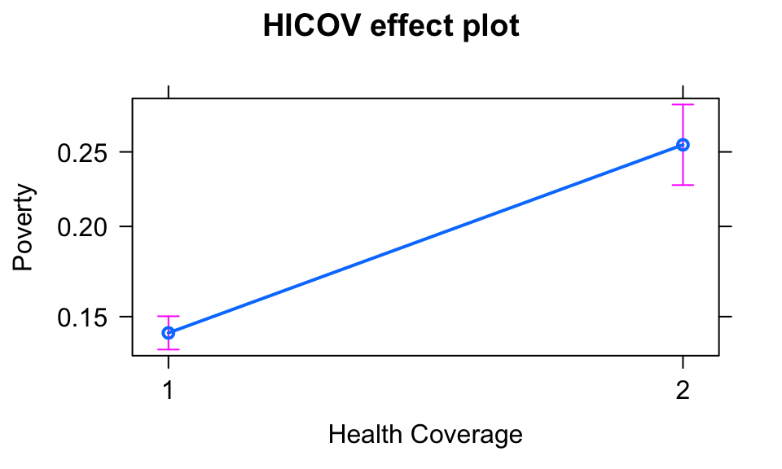

```r
plotEffect(eff, cName='HICOV', mtitle = 'HICOV effect plot', xtitle = 'Poverty', ytitle = 'Health Coverage')
```

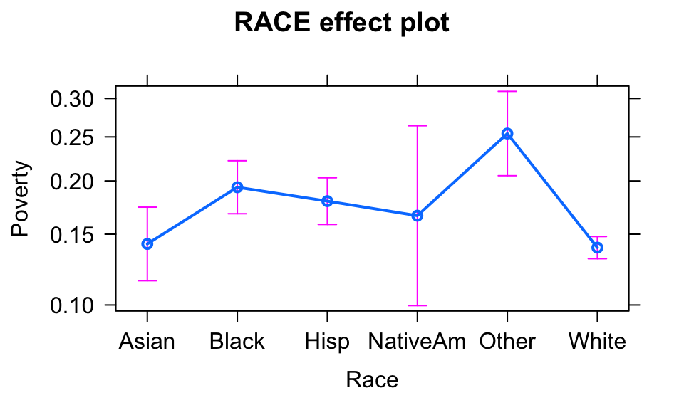

```r
plotEffect(eff, cName='RACE', mtitle = 'RACE effect plot', xtitle = 'Poverty', ytitle = 'Race')
```

### Conclusion

It appears that Age, Sex, Maritial Status and Education are statistically signifigant in determining Income Levels. Race is a factor but less of an influence when Education is included from the model. Age, Gender and Education have the strongest affects.

In terms of predictors for poverty, Age, Gender, Health Coverage and Race are statistically signfifant, though Race much less so given the inclusion of Education. Age, College attainment and Health coverage are the strongest predictors.

Looking ahead, I would like to review the influence of Occupation and Industry on income levels. I’m would assume both have a large effect given that much of income disparity income relates to occupation; women, even those with higher levels of education, tend to work more in lower paying occupations such as nonprofit, teaching, etc.. and are underrepresented in top management/executive positions.